# Capston Project - Marketing campaign

```python
import pandas as pd
import numpy as np
import matplotlib.pyplot as plt
import seaborn as sns
# Python
import warnings

# Suppress all warnings
warnings.filterwarnings("ignore")
```

```python
df= pd.read_csv("bank-full.csv", sep=";")
df.head()
```

|  | age | job | marital | education | default | balance | housing | loan | contact | day | month | duration | campaign | pdays | previous | poutcome | y |
| --- | --- | --- | --- | --- | --- | --- | --- | --- | --- | --- | --- | --- | --- | --- | --- | --- | --- |
| 0 | 58 | management | married | tertiary | no | 2143 | yes | no | unknown | 5 | may | 261 | 1 | -1 | 0 | unknown | no |
| 1 | 44 | technician | single | secondary | no | 29 | yes | no | unknown | 5 | may | 151 | 1 | -1 | 0 | unknown | no |
| 2 | 33 | entrepreneur | married | secondary | no | 2 | yes | yes | unknown | 5 | may | 76 | 1 | -1 | 0 | unknown | no |
| 3 | 47 | blue-collar | married | unknown | no | 1506 | yes | no | unknown | 5 | may | 92 | 1 | -1 | 0 | unknown | no |
| 4 | 33 | unknown | single | unknown | no | 1 | no | no | unknown | 5 | may | 198 | 1 | -1 | 0 | unknown | no |

```python
df.info()
```

```
<class 'pandas.core.frame.DataFrame'>
RangeIndex: 45211 entries, 0 to 45210
Data columns (total 17 columns):
 #   Column     Non-Null Count  Dtype
---  ------     --------------  -----
 0   age        45211 non-null  int64
 1   job        45211 non-null  object
 2   marital    45211 non-null  object
 3   education  45211 non-null  object
 4   default    45211 non-null  object
 5   balance    45211 non-null  int64
 6   housing    45211 non-null  object
 7   loan       45211 non-null  object
 8   contact    45211 non-null  object
 9   day        45211 non-null  int64
 10  month      45211 non-null  object
 11  duration   45211 non-null  int64
 12  campaign   45211 non-null  int64
 13  pdays      45211 non-null  int64
 14  previous   45211 non-null  int64
 15  poutcome   45211 non-null  object
 16  y          45211 non-null  object
dtypes: int64(7), object(10)
memory usage: 5.9+ MB
```

## Univariate analysis for categorical and object variables

```python
# Univariate analysis of categorical and object variables

def plot_object(dataframe, column_name):
 """
 Plots a bar chart showing category frequencies with both frequency (inside bar)
 and proportion (above bar) labels.
 Parameters:- dataframe: pandas DataFrame- column_name: str, name of the categorical column to visualize
 """
 # Count frequencies and proportions
 value_counts = dataframe[column_name].value_counts()
 proportions = value_counts / len(dataframe)
 # Set plot style
 sns.set(style="whitegrid")
 plt.figure(figsize=(10, 6))
 # Bar plot
 palette1=sns.color_palette(palette='tab20')
 ax = sns.barplot(x=value_counts.index, y=value_counts.values, palette=palette1)
 # Annotate bars
 for i, (count, prop) in enumerate(zip(value_counts.values, proportions.values)):
 # Frequency inside bar
   ax.text(i, count * 0.5, f'{count}', ha='center', va='center',fontsize=11, color='black', fontweight='bold')
 # Proportion above bar
   ax.text(i, count + max(value_counts.values) * 0.02, f'{prop:.2%}',ha='center', fontsize=10, color='black')
 plt.title(f'Distribution of {column_name}')
 plt.xlabel(column_name)
 plt.xticks(rotation=90)
 plt.ylabel('Frequency')
 plt.tight_layout()
 plt.show()
```

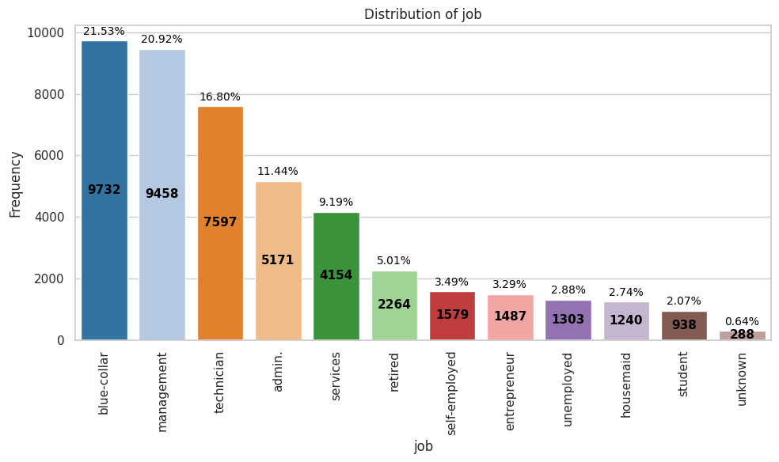

```python
plot_object(df, "job")
```

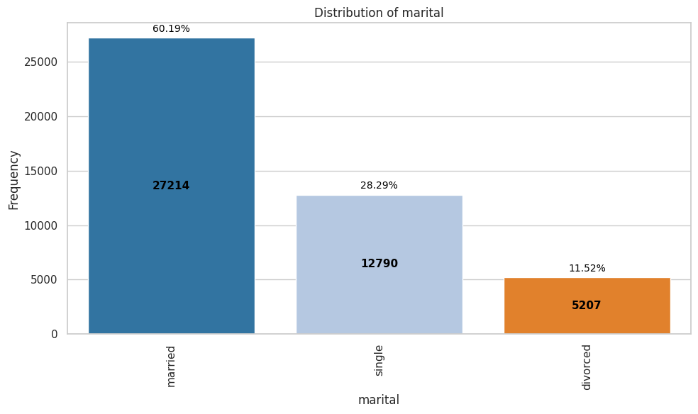

```python
plot_object(df, 'marital')
```

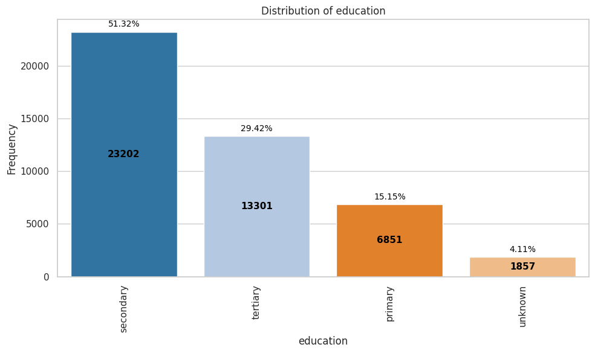

```python
plot_object(df, 'education')
```

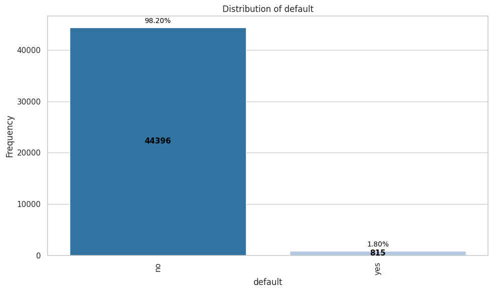

```python
plot_object(df, 'default')
```

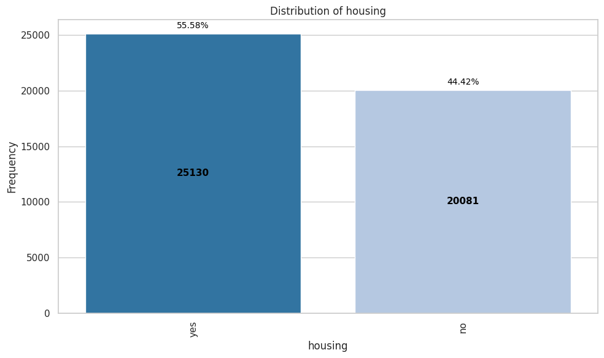

```python
plot_object(df, 'housing')
```

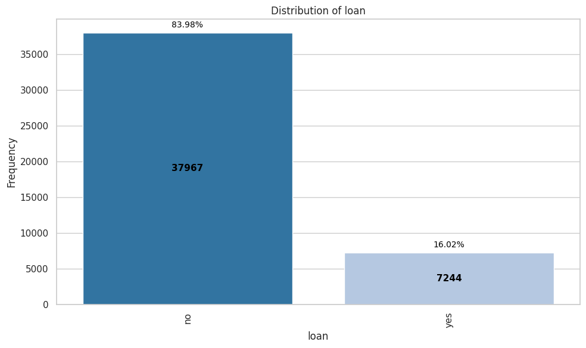

```python
plot_object(df, 'loan')
```

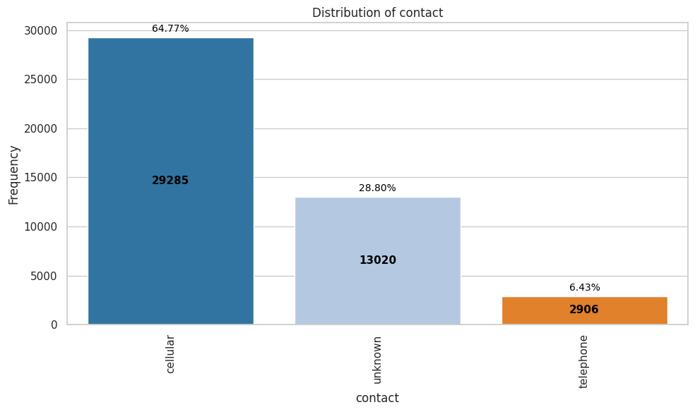

```python
plot_object(df, 'contact')
```

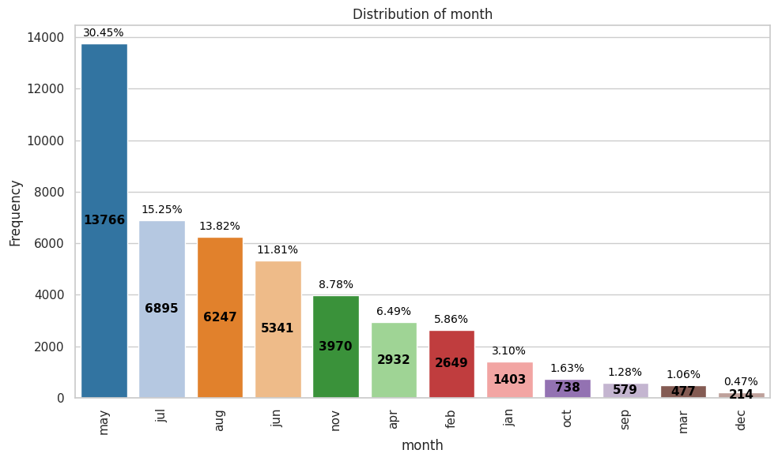

```python
plot_object(df, 'month')
```

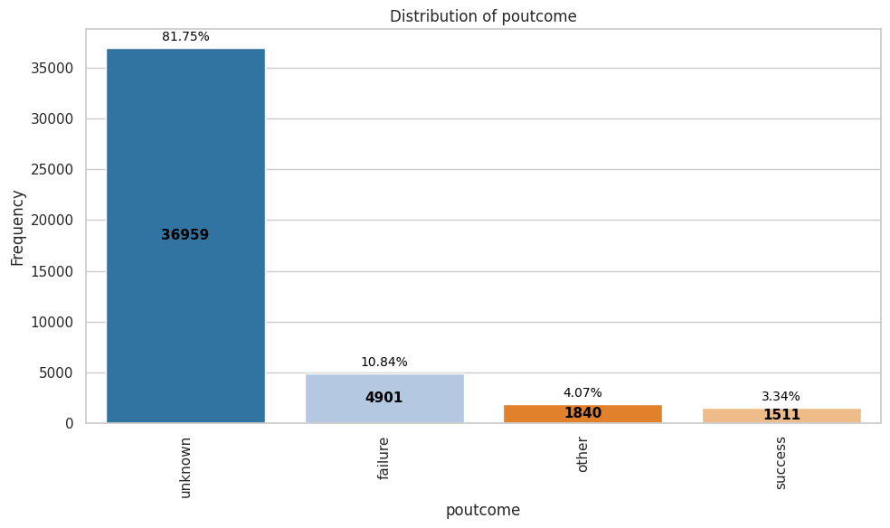

```python
plot_object(df, 'poutcome')
```

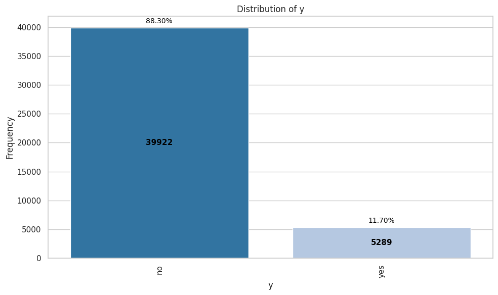

```python
plot_object(df, 'y')
```

## Univariate Analysis for numerical variables

```python
# univariate analysis of continuous variables
def cont_plot(df, var):
 #var="Age"
 # Set plot style
 sns.set(style="whitegrid")
 # Create a figure with two subplots: histogram and box plot
 plt.figure(figsize=(12, 6))
 # Histogram
 # Box plot
 plt.subplot(1, 2, 1)
 sns.histplot(df[var], bins=20, kde=True, color='red')
 plt.title(var+' Distribution- Histogram')
 plt.xlabel(var)
 plt.ylabel('Frequency')
 plt.subplot(1, 2, 2)
 sns.boxplot(x=df[var], color='yellow')
 plt.title(var+' Distribution- Box Plot')
```

```python
def NoOutlier(df,var):
    sns.boxplot(x=df[var], showfliers=False,color="yellow")
    plt.title("Boxplot of "+ var +" (without outliers)")
    plt.show()
```

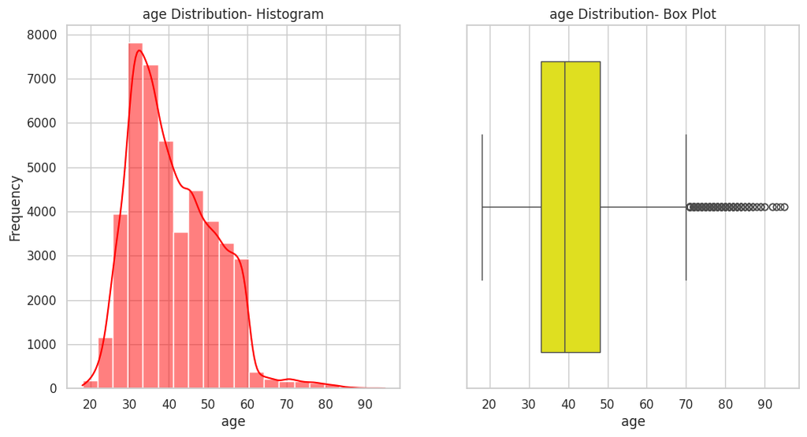

```python
cont_plot(df,'age' )
```

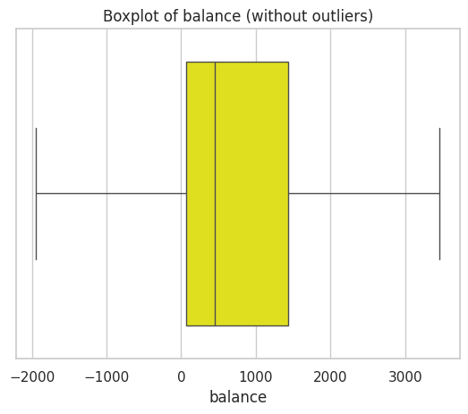

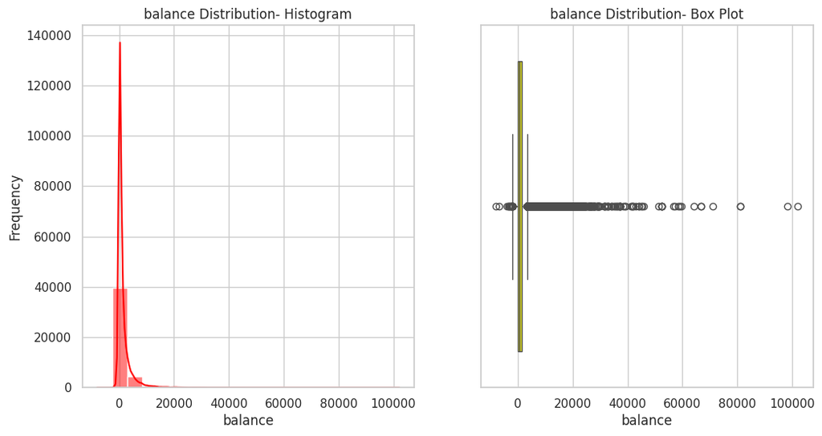

```python
# Boxplot without outliers
NoOutlier(df,"balance")
cont_plot(df,'balance' )
```

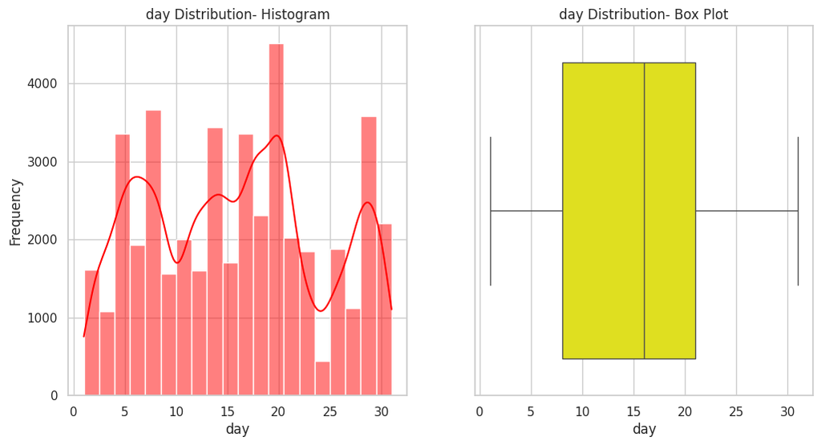

```python
cont_plot(df,'day' )
```

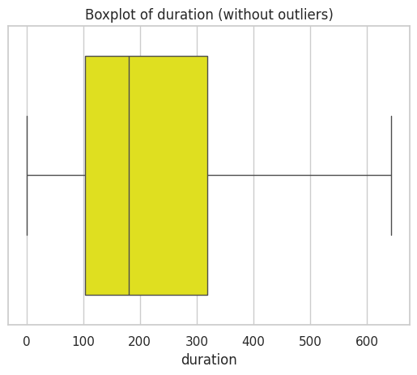

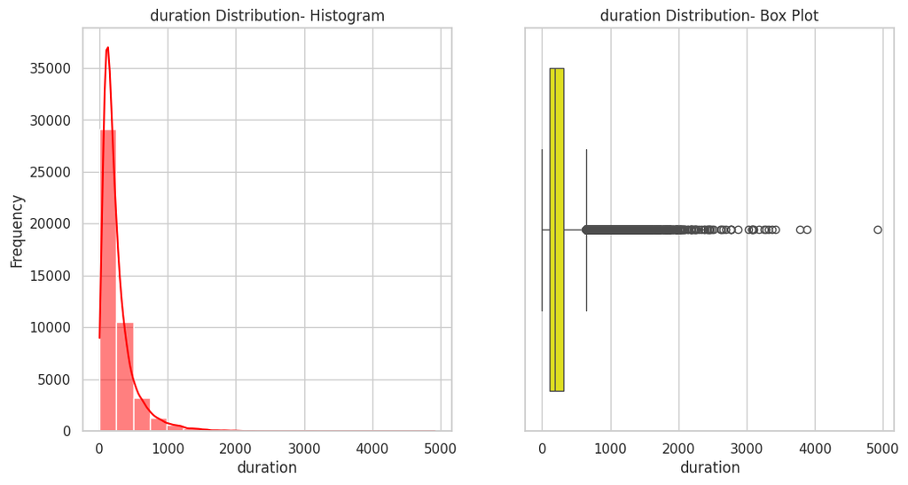

```python
NoOutlier(df,"duration")
cont_plot(df,'duration' )
```

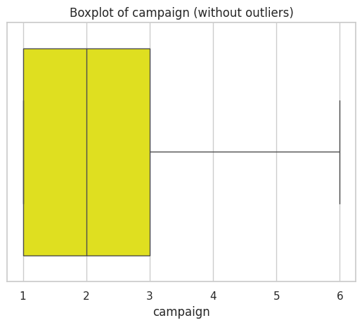

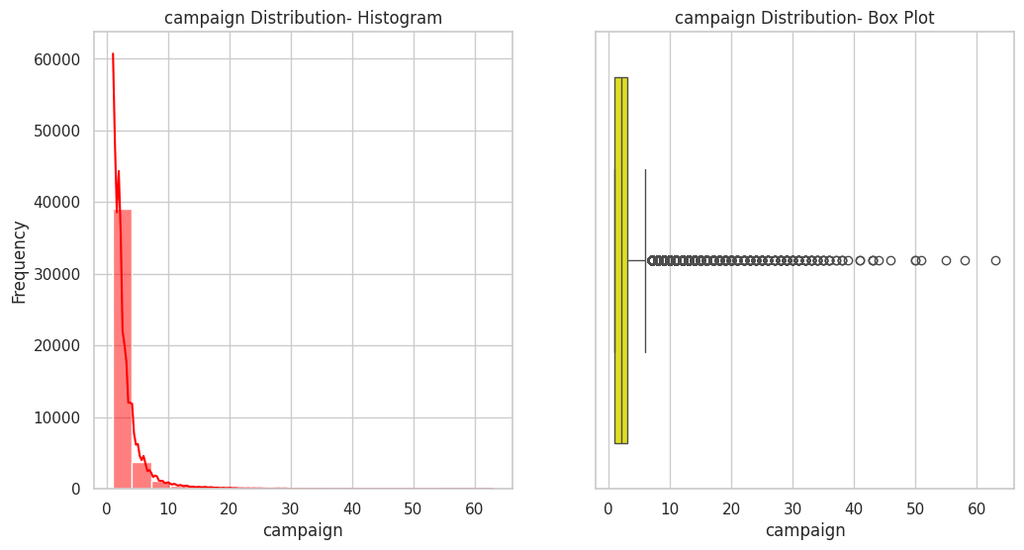

```python
NoOutlier(df,"campaign")
cont_plot(df,'campaign' )
```

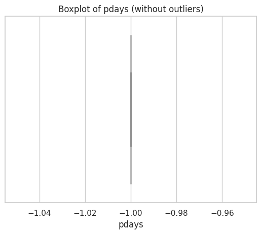

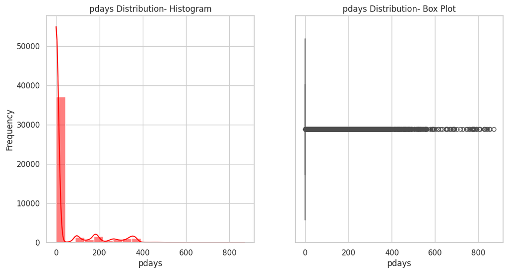

```python
NoOutlier(df,"pdays")
cont_plot(df,'pdays' )
```

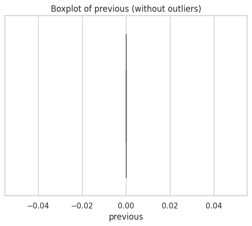

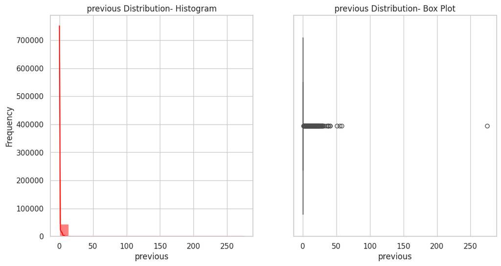

```python
NoOutlier(df,"previous")
cont_plot(df,'previous' )
```

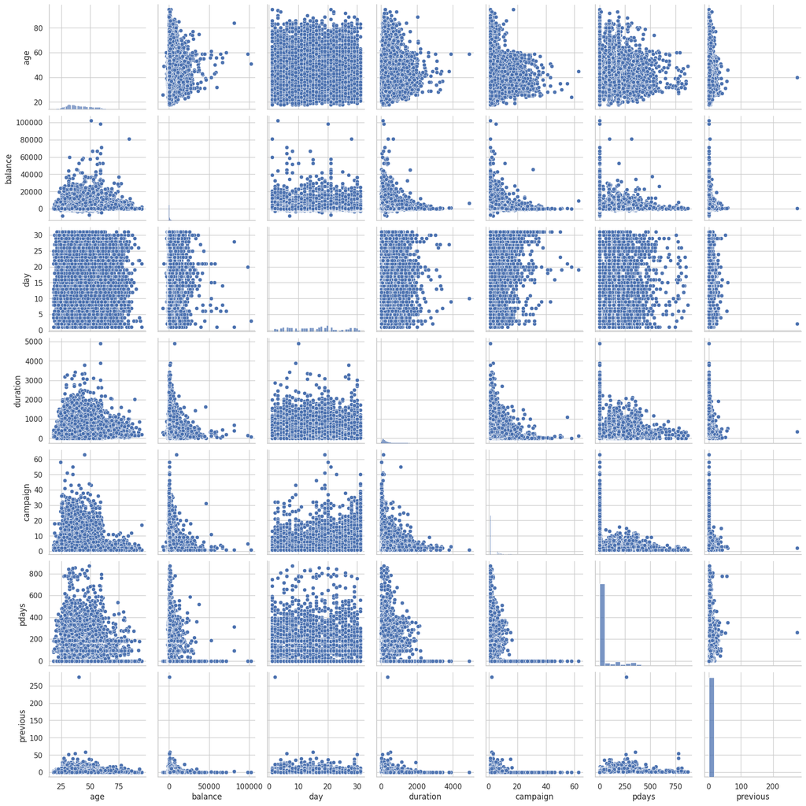

```python
import seaborn as sns
import matplotlib.pyplot as plt

# Pairwise scatter plots for numerical variables
sns.pairplot(df.select_dtypes(include=['number']))
plt.show()
```

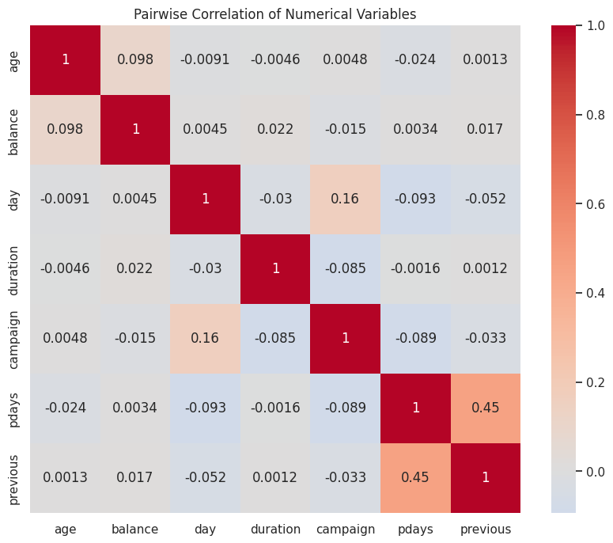

```python
import seaborn as sns
import matplotlib.pyplot as plt

# Compute correlation matrix
corr_matrix = df.select_dtypes(include=['number']).corr()

# Plot heatmap
plt.figure(figsize=(10, 8))
sns.heatmap(corr_matrix, annot=True, cmap='coolwarm', center=0)
plt.title("Pairwise Correlation of Numerical Variables")
plt.show()
```

```python
int_columns = df.select_dtypes('int64').columns.tolist()

print(int_columns)
```

```
['age', 'balance', 'day', 'duration', 'campaign', 'pdays', 'previous']
```

```python
object_columns = df.select_dtypes(include=['object']).columns.tolist()

print(object_columns)
```

```
['job', 'marital', 'education', 'default', 'housing', 'loan', 'contact', 'month', 'poutcome', 'y']
```

```python
def cat_cont_plot(df, xvar, yvar):
    """
    Creates histograms of a continuous variable across categories.

    Parameters:
    - df: pandas DataFrame
    - xvar: str, categorical column name (e.g. 'Target')
    - yvar: str, continuous column name (e.g. 'Age')
    """
    sns.boxplot(x=xvar, y=yvar, data=df, color="pink")
    plt.xticks(rotation=90)


    # Create a larger facet grid of histograms by category
    #g = sns.FacetGrid(df, col=xvar, col_wrap=4, height=6, aspect=0.5)  # Increased size and layout
    #g.map(sns.histplot, yvar, bins=20, color="green")

    # Add titles and labels
    #g.set_axis_labels(yvar, "Frequency")
    #g.set_titles(col_template="{col_name}")
   # plt.tight_layout()
    plt.show()
```

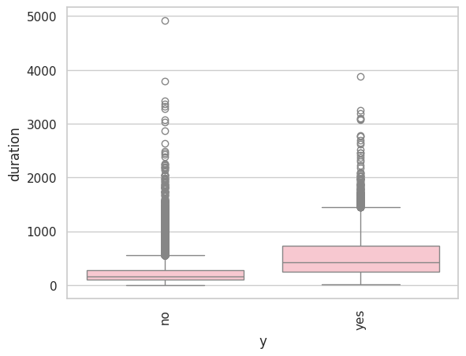

```python
cat_cont_plot(df,"y", "duration")
```

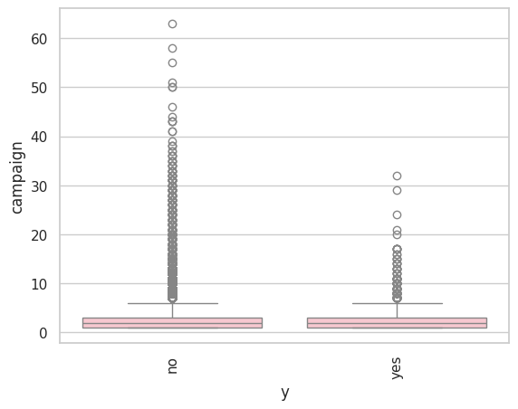

```python
cat_cont_plot(df,"y", "campaign")
```

```python
def cat_cat_plot(dataframe, column_name, hue_column):
    """
    Plots a grouped bar chart showing category frequencies split by hue,
    with both frequency (inside bar) and proportion (above bar) labels.

    Parameters:
    - dataframe: pandas DataFrame
    - column_name: str, name of the categorical column to visualize (x-axis)
    - hue_column: str, name of the second categorical variable to group by (hue)
    """
    # Count combinations of column and hue
    counts_df = dataframe.groupby([column_name, hue_column]).size().reset_index(name='count')
    total_counts = dataframe[column_name].value_counts()

    # Set plot style
    sns.set(style="whitegrid")
    plt.figure(figsize=(14, 8))  # Larger frame

    # Create bar plot
    ax = sns.barplot(x=column_name, y='count', hue=hue_column, data=counts_df, palette="muted")
    # Annotate bars
    for container in ax.containers:
        for bar in container:
            height = bar.get_height()
            x = bar.get_x() + bar.get_width() / 2
            category = bar.get_label()
            base_x = int(round(x))  # used for proportion lookup
            if height > 0:
                ax.text(x, height * 0.5, f'{int(height)}', ha='center', va='center',
                        fontsize=10, color='black', fontweight='bold')
                ax.text(x, height + max(counts_df['count']) * 0.02, f'{height / sum(container.datavalues):.1%}',
                        ha='center', fontsize=10, color='navy', fontweight='bold')


    # Beautify plot
    plt.title(f'{column_name} Distribution by {hue_column}', fontsize=16)
    plt.xlabel(column_name, fontsize=23)
    plt.ylabel('Frequency', fontsize=19)
    plt.xticks(rotation=45)
    plt.legend(title=hue_column)
    plt.tight_layout()
    plt.show()
```

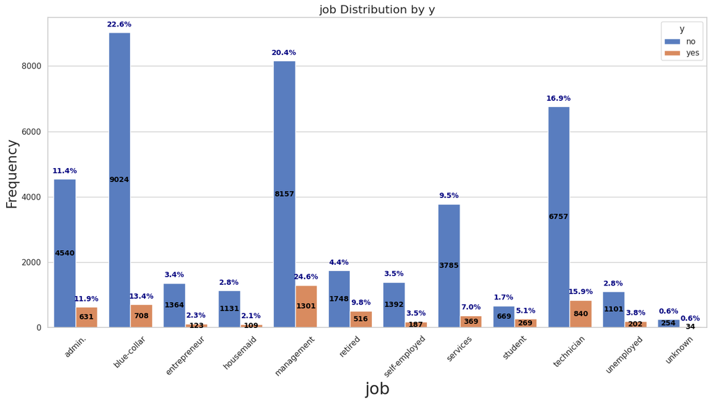

```python
cat_cat_plot(df,'job',"y")
```

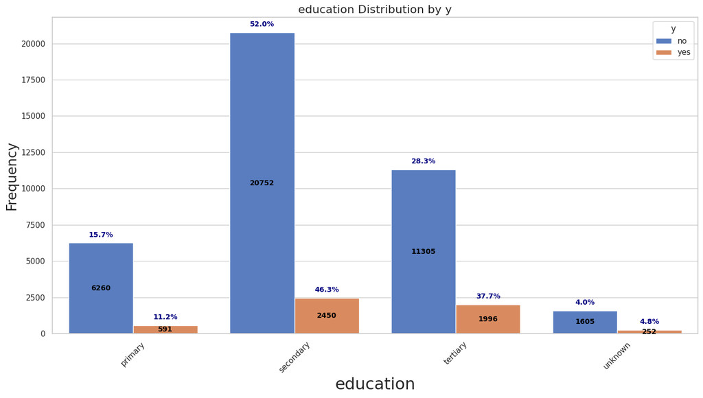

```python
cat_cat_plot(df,'education',"y")
```

```python
#import numpy as np

# Indicator: whether client was contacted before
df['previous_contact'] = (df['pdays'] != -1).astype(int)

# Replace -1 with NaN so pdays is only meaningful when contact exists
df['pdays'] = df['pdays'].replace(-1, np.nan)
```

# Research Question 1: Which customer and campaign features best predict term deposit subscription?

```python
rq1_vars=["age", "job","education", "marital", "balance", "default", "housing","loan", "contact","duration", "poutcome", "previous","campaign" , "contact",'previous_contact','pdays',"y"]
```

```python
dfrq1=df[rq1_vars]
```

```python
dfrq1.head()
```

|  | age | job | education | marital | balance | default | housing | loan | contact | duration | poutcome | previous | campaign | contact | previous_contact | pdays | y |
| --- | --- | --- | --- | --- | --- | --- | --- | --- | --- | --- | --- | --- | --- | --- | --- | --- | --- |
| 0 | 58 | management | tertiary | married | 2143 | no | yes | no | unknown | 261 | unknown | 0 | 1 | unknown | 0 | NaN | no |
| 1 | 44 | technician | secondary | single | 29 | no | yes | no | unknown | 151 | unknown | 0 | 1 | unknown | 0 | NaN | no |
| 2 | 33 | entrepreneur | secondary | married | 2 | no | yes | yes | unknown | 76 | unknown | 0 | 1 | unknown | 0 | NaN | no |
| 3 | 47 | blue-collar | unknown | married | 1506 | no | yes | no | unknown | 92 | unknown | 0 | 1 | unknown | 0 | NaN | no |
| 4 | 33 | unknown | unknown | single | 1 | no | no | no | unknown | 198 | unknown | 0 | 1 | unknown | 0 | NaN | no |

## Preprocessing

```python
dfrq1.info()
```

```
<class 'pandas.core.frame.DataFrame'>
RangeIndex: 45211 entries, 0 to 45210
Data columns (total 17 columns):
 #   Column            Non-Null Count  Dtype
---  ------            --------------  -----
 0   age               45211 non-null  int64
 1   job               45211 non-null  object
 2   education         45211 non-null  object
 3   marital           45211 non-null  object
 4   balance           45211 non-null  int64
 5   default           45211 non-null  object
 6   housing           45211 non-null  object
 7   loan              45211 non-null  object
 8   contact           45211 non-null  object
 9   duration          45211 non-null  int64
 10  poutcome          45211 non-null  object
 11  previous          45211 non-null  int64
 12  campaign          45211 non-null  int64
 13  contact           45211 non-null  object
 14  previous_contact  45211 non-null  int64
 15  pdays             8257 non-null   float64
 16  y                 45211 non-null  object
dtypes: float64(1), int64(6), object(10)
memory usage: 5.9+ MB
```

```python
dfrq1.shape
```

```
(45211, 17)
```

### Ecoding all object variables into dummy variable.

```python
cat_cols = dfrq1.select_dtypes(include='object').columns

dfrq1_enc = pd.get_dummies(dfrq1, columns=cat_cols, drop_first=True)

print(dfrq1_enc.shape)
print(dfrq1_enc.head())
```

```
(45211, 38)
   age  balance  duration  previous  campaign  previous_contact  pdays  \
0   58     2143       261         0         1                 0    NaN
1   44       29       151         0         1                 0    NaN
2   33        2        76         0         1                 0    NaN
3   47     1506        92         0         1                 0    NaN
4   33        1       198         0         1                 0    NaN

   job_blue-collar  job_entrepreneur  job_housemaid  ...  contact_telephone  \
0                0                 0              0  ...                  0
1                0                 0              0  ...                  0
2                0                 1              0  ...                  0
3                1                 0              0  ...                  0
4                0                 0              0  ...                  0

```

[output cut: 22 more lines]

```python
from sklearn.model_selection import train_test_split

X = dfrq1_enc.drop(columns=['y_yes'])
y = dfrq1_enc['y_yes']
```

```python
#Train–test split (stratified)
from sklearn.model_selection import train_test_split

X_train, X_test, y_train, y_test = train_test_split( X, y,
    test_size=0.3,
    stratify=y,
    random_state=42
)
```

Given the presence of substantial outliers in several numerical variables, RobustScaler was used to scale the features, as it relies on the median and interquartile range and is less sensitive to extreme values.

Since pdays is undefined for clients never previously contacted, a binary indicator was introduced to represent prior contact status. Remaining missing values in pdays were imputed using the median to avoid introducing artificial extremes.

The variable pdays uses the value −1 to indicate clients who were never previously contacted. As this value is not a valid numerical quantity, it was replaced with missing values, and a binary indicator variable (previous_contact) was created to capture prior contact status. Since logistic regression does not handle missing values natively, a median imputation strategy was applied within a modeling pipeline prior to robust scaling and model fitting. RobustScaler was used due to the presence of substantial outliers in several numerical variables.

```python
from sklearn.pipeline import Pipeline
from sklearn.impute import SimpleImputer
from sklearn.preprocessing import RobustScaler
from sklearn.linear_model import LogisticRegression

log_reg_pipeline = Pipeline(steps=[
    ('imputer', SimpleImputer(strategy='median')),   # handles NaNs (pdays)
    ('scaler', RobustScaler()),                      # robust to outliers
    ('model', LogisticRegression(
        max_iter=1000,
        class_weight='balanced',
        random_state=42
    ))
])
```

```python
log_reg_pipeline.fit(X_train, y_train)
```

```
Pipeline(steps=[('imputer', SimpleImputer(strategy='median')),
                ('scaler', RobustScaler()),
                ('model',
                 LogisticRegression(class_weight='balanced', max_iter=1000,
                                    random_state=42))])
```

**Model evaluation**

```python
from sklearn.metrics import confusion_matrix, classification_report

y_pred = log_reg_pipeline.predict(X_test)

cm = confusion_matrix(y_test, y_pred)
print(cm)
```

```
[[10002  1975]
 [  341  1246]]
```

```python
print(classification_report(y_test, y_pred))
```

```
              precision    recall  f1-score   support

           0       0.97      0.84      0.90     11977
           1       0.39      0.79      0.52      1587

    accuracy                           0.83     13564
   macro avg       0.68      0.81      0.71     13564
weighted avg       0.90      0.83      0.85     13564
```

```python
#ROC–AUC
from sklearn.metrics import roc_auc_score

y_prob = log_reg_pipeline.predict_proba(X_test)[:, 1]
roc_auc = roc_auc_score(y_test, y_prob)

print("ROC-AUC:", roc_auc)
```

```
ROC-AUC: 0.89182053883049
```

**Interpret coefficients**

```python
import pandas as pd
import numpy as np

coef = log_reg_pipeline.named_steps['model'].coef_[0]

coef_df = pd.DataFrame({
    'Feature': X.columns,
    'Coefficient': coef,
    'Odds_Ratio': np.exp(coef)
}).sort_values(by='Odds_Ratio', ascending=False)

coef_df
```

|  | Feature | Coefficient | Odds_Ratio |
| --- | --- | --- | --- |
| 31 | poutcome_success | 2.385626 | 10.865859 |
| 2 | duration | 1.193241 | 3.297752 |
| 14 | job_student | 0.568677 | 1.765929 |
| 19 | education_tertiary | 0.518236 | 1.679063 |
| 11 | job_retired | 0.424058 | 1.528151 |
| 20 | education_unknown | 0.307635 | 1.360205 |
| 30 | poutcome_other | 0.260160 | 1.297138 |
| 18 | education_secondary | 0.258276 | 1.294695 |
| 22 | marital_single | 0.189902 | 1.209131 |
| 5 | previous_contact | 0.177928 | 1.194740 |
| 1 | balance | 0.040230 | 1.041050 |
| 3 | previous | 0.030356 | 1.030821 |
| 35 | contact_telephone | 0.012216 | 1.012291 |
| 33 | contact_telephone | 0.012216 | 1.012291 |
| 28 | contact_telephone | 0.012216 | 1.012291 |
| 26 | contact_telephone | 0.012216 | 1.012291 |
| 0 | age | 0.009416 | 1.009460 |
| 6 | pdays | 0.000241 | 1.000241 |
| 32 | poutcome_unknown | -0.101671 | 0.903327 |
| 21 | marital_married | -0.178142 | 0.836823 |
| 10 | job_management | -0.203363 | 0.815982 |
| 4 | campaign | -0.236401 | 0.789464 |
| 23 | default_yes | -0.252914 | 0.776535 |
| 16 | job_unemployed | -0.272010 | 0.761847 |
| 15 | job_technician | -0.322706 | 0.724186 |
| 36 | contact_unknown | -0.332182 | 0.717357 |
| 29 | contact_unknown | -0.332182 | 0.717357 |
| 34 | contact_unknown | -0.332182 | 0.717357 |
| 27 | contact_unknown | -0.332182 | 0.717357 |
| 17 | job_unknown | -0.345373 | 0.707957 |
| 13 | job_services | -0.448088 | 0.638848 |
| 8 | job_entrepreneur | -0.529650 | 0.588811 |
| 9 | job_housemaid | -0.533286 | 0.586674 |
| 7 | job_blue-collar | -0.536965 | 0.584520 |
| 12 | job_self-employed | -0.538566 | 0.583585 |
| 25 | loan_yes | -0.687911 | 0.502625 |
| 24 | housing_yes | -0.849760 | 0.427518 |

Interpretation rule:

Odds Ratio > 1 → increases probability of subscription

Odds Ratio < 1 → decreases probability

```python
#Extract coefficients and odds ratios from the pipeline
import pandas as pd
import numpy as np

# Extract coefficients
coef = log_reg_pipeline.named_steps['model'].coef_[0]

coef_df = pd.DataFrame({
    'Feature': X.columns,
    'Coefficient': coef,
    'Odds_Ratio': np.exp(coef)
})

coef_df = coef_df.sort_values(by='Odds_Ratio', ascending=False)
```

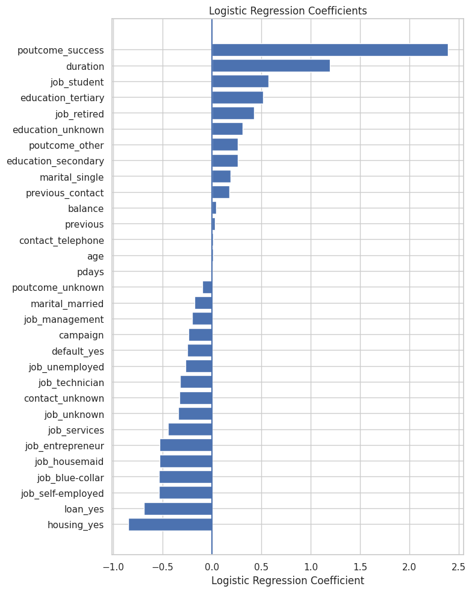

```python
#Visualise coefficients (direction + strength)
import matplotlib.pyplot as plt

plt.figure(figsize=(8, 10))
plt.barh(coef_df['Feature'], coef_df['Coefficient'])
plt.axvline(0)
plt.xlabel('Logistic Regression Coefficient')
plt.title('Logistic Regression Coefficients')
plt.gca().invert_yaxis()
plt.tight_layout()
plt.show()
```

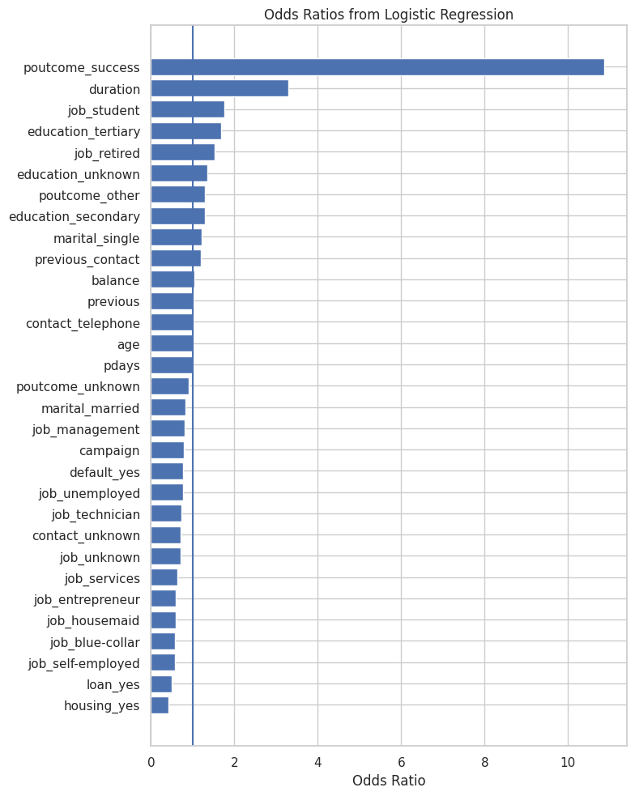

```python
#Visualise odds ratios
plt.figure(figsize=(8, 10))
plt.barh(coef_df['Feature'], coef_df['Odds_Ratio'])
plt.axvline(1)
plt.xlabel('Odds Ratio')
plt.title('Odds Ratios from Logistic Regression')
plt.gca().invert_yaxis()
plt.tight_layout()
plt.show()
```

# Random forest

```python
X = dfrq1_enc.drop(columns=['y_yes'])
y = dfrq1_enc['y_yes']
```

```python
from sklearn.model_selection import train_test_split

X_train_rf, X_test_rf, y_train_rf, y_test_rf = train_test_split(
    X, y,
    test_size=0.3,
    stratify=y,
    random_state=42
)
```

## Fit Random Forest (no scaling needed)

Random Forest does NOT need scaling and handles outliers naturally.

```python
from sklearn.ensemble import RandomForestClassifier

rf = RandomForestClassifier(
    n_estimators=300,
    max_depth=None,
    min_samples_leaf=5,
    class_weight='balanced',
    random_state=42,
    n_jobs=-1
)

rf.fit(X_train_rf, y_train_rf)
```

```
RandomForestClassifier(class_weight='balanced', min_samples_leaf=5,
                       n_estimators=300, n_jobs=-1, random_state=42)
```

**Model evaluation**

```python
from sklearn.metrics import confusion_matrix, classification_report, roc_auc_score

y_pred = rf.predict(X_test)
y_prob = rf.predict_proba(X_test)[:, 1]

print("Confusion Matrix:\n", confusion_matrix(y_test, y_pred))
print("\nClassification Report:\n", classification_report(y_test, y_pred))
print("ROC-AUC:", roc_auc_score(y_test, y_prob))
```

```
Confusion Matrix:
 [[10494  1483]
 [  384  1203]]

Classification Report:
               precision    recall  f1-score   support

           0       0.96      0.88      0.92     11977
           1       0.45      0.76      0.56      1587

    accuracy                           0.86     13564
   macro avg       0.71      0.82      0.74     13564
weighted avg       0.90      0.86      0.88     13564

ROC-AUC: 0.9014899329996021
```

**Feature importance**

```python
import pandas as pd

feature_importance = pd.DataFrame({
    'Feature': X.columns,
    'Importance': rf.feature_importances_
}).sort_values(by='Importance', ascending=False)

feature_importance.head(15)
```

|  | Feature | Importance |
| --- | --- | --- |
| 2 | duration | 0.468353 |
| 1 | balance | 0.078820 |
| 0 | age | 0.073920 |
| 31 | poutcome_success | 0.051599 |
| 6 | pdays | 0.042453 |
| 24 | housing_yes | 0.035750 |
| 4 | campaign | 0.035113 |
| 27 | contact_unknown | 0.020728 |
| 34 | contact_unknown | 0.020588 |
| 29 | contact_unknown | 0.020351 |
| 36 | contact_unknown | 0.017481 |
| 3 | previous | 0.015889 |
| 25 | loan_yes | 0.010693 |
| 21 | marital_married | 0.010467 |
| 5 | previous_contact | 0.009960 |

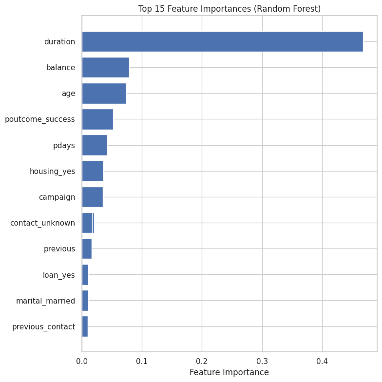

```python
#Visualise top feature importances
import matplotlib.pyplot as plt

top_features = feature_importance.head(15)

plt.figure(figsize=(8, 8))
plt.barh(top_features['Feature'], top_features['Importance'])
plt.xlabel('Feature Importance')
plt.title('Top 15 Feature Importances (Random Forest)')
plt.gca().invert_yaxis()
plt.tight_layout()
plt.show()
```

A Random Forest classifier was trained to identify key customer and campaign features associated with term deposit subscription. As a tree-based model, Random Forest does not require feature scaling and is robust to outliers. Class imbalance was addressed using balanced class weights. Model performance was evaluated using recall, F1-score, and ROC–AUC. Feature importance scores were extracted to identify the most influential predictors.

## SHAP

```python
# Take a random sample of the test set
X_test_shap = X_test.sample(n=1000, random_state=42)
```

```python
import shap

explainer = shap.TreeExplainer(rf)

shap_values = explainer.shap_values(X_test_shap)
```

```
100%|===================| 1998/2000 [02:38<00:00]
```

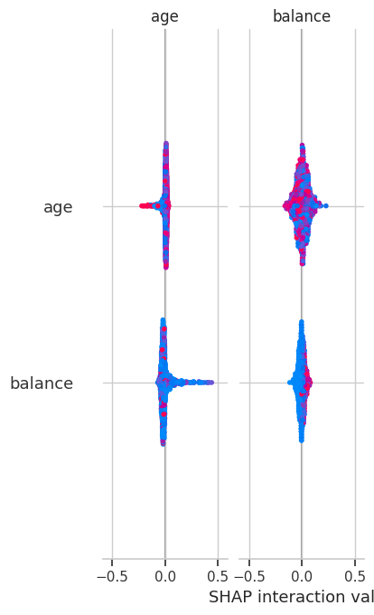

```python
import shap

# Use the unified SHAP API
explainer = shap.Explainer(rf, X_train)

# Compute SHAP values on the sample
shap_values = explainer(X_test_shap)

# Summary plot (this WILL work)
shap.summary_plot(
    shap_values.values,
    X_test_shap,
    plot_type="dot",
    show=True
)
```

```python
# --------------------------------------------------
# 5. Compute SHAP INTERACTION values (slow but needed once)
# --------------------------------------------------
shap_interaction_values = explainer.shap_interaction_values(X_test_shap)

# For binary classification: take positive class ("yes")
shap_inter_pos = shap_interaction_values[:, :, 1]

# --------------------------------------------------
# 6. Quantify MAIN vs INTERACTION effects
# --------------------------------------------------
# ---- MAIN EFFECTS (positive class only) ----
shap_main = np.mean(
    np.abs(shap_values.values[:, :, 1]),  # class "yes"
    axis=0
)
# Mean absolute MAIN effects per feature
#shap_main = np.mean(np.abs(shap_values.values), axis=0)

# Mean absolute INTERACTION effects
shap_inter = np.mean(np.abs(shap_inter_pos), axis=0)

# Remove self-interactions (diagonal)
np.fill_diagonal(shap_inter, 0)

# Aggregate interaction strength per feature
interaction_strength = shap_inter.sum(axis=1)

# --------------------------------------------------
# 7. Comparison table (proof of weak interactions)
# --------------------------------------------------
comparison = pd.DataFrame({
    "feature": X_test_shap.columns,
    "main_effect": shap_main,
    "interaction_effect": interaction_strength,
    "interaction_ratio": interaction_strength / shap_main
}).sort_values("interaction_ratio", ascending=False)

comparison
```

```
FEATURE_DEPENDENCE::independent does not support interactions!
```

|  | feature | main_effect | interaction_effect | interaction_ratio |
| --- | --- | --- | --- | --- |
| 0 | age | 0.016193 | 0.0 | 0.0 |
| 19 | education_tertiary | 0.011398 | 0.0 | 0.0 |
| 21 | marital_married | 0.010235 | 0.0 | 0.0 |
| 22 | marital_single | 0.006799 | 0.0 | 0.0 |
| 23 | default_yes | 0.000343 | 0.0 | 0.0 |
| 24 | housing_yes | 0.034003 | 0.0 | 0.0 |
| 25 | loan_yes | 0.010002 | 0.0 | 0.0 |
| 26 | contact_telephone | 0.000414 | 0.0 | 0.0 |
| 27 | contact_unknown | 0.014227 | 0.0 | 0.0 |
| 28 | contact_telephone | 0.000433 | 0.0 | 0.0 |
| 29 | contact_unknown | 0.013769 | 0.0 | 0.0 |
| 30 | poutcome_other | 0.001024 | 0.0 | 0.0 |
| 31 | poutcome_success | 0.017082 | 0.0 | 0.0 |
| 32 | poutcome_unknown | 0.007596 | 0.0 | 0.0 |
| 33 | contact_telephone | 0.000420 | 0.0 | 0.0 |
| 34 | contact_unknown | 0.013588 | 0.0 | 0.0 |
| 35 | contact_telephone | 0.000501 | 0.0 | 0.0 |
| 20 | education_unknown | 0.000665 | 0.0 | 0.0 |
| 18 | education_secondary | 0.002449 | 0.0 | 0.0 |
| 1 | balance | 0.020787 | 0.0 | 0.0 |
| 17 | job_unknown | 0.000015 | 0.0 | 0.0 |
| 2 | duration | 0.134506 | 0.0 | 0.0 |
| 3 | previous | 0.008536 | 0.0 | 0.0 |
| 4 | campaign | 0.017766 | 0.0 | 0.0 |
| 5 | previous_contact | 0.008049 | 0.0 | 0.0 |
| 6 | pdays | 0.013353 | 0.0 | 0.0 |
| 7 | job_blue-collar | 0.005185 | 0.0 | 0.0 |
| 8 | job_entrepreneur | 0.000691 | 0.0 | 0.0 |
| 9 | job_housemaid | 0.000449 | 0.0 | 0.0 |
| 10 | job_management | 0.003651 | 0.0 | 0.0 |
| 11 | job_retired | 0.001034 | 0.0 | 0.0 |
| 12 | job_self-employed | 0.000531 | 0.0 | 0.0 |
| 13 | job_services | 0.001159 | 0.0 | 0.0 |
| 14 | job_student | 0.001493 | 0.0 | 0.0 |
| 15 | job_technician | 0.002351 | 0.0 | 0.0 |
| 16 | job_unemployed | 0.000379 | 0.0 | 0.0 |
| 36 | contact_unknown | 0.012287 | 0.0 | 0.0 |

Methods / Explainability section

SHAP interaction values were computed on a representative subset of the test data to assess whether the Random Forest model relied on nonlinear feature interactions. Interaction effects were quantified and compared to main feature effects using the ratio of interaction strength to main effect magnitude.